```python
import numpy as np #importing numpy and renaming .numpy to .np
```

# 2 think+type: numpy arrays

```python
list1 = [-2, -1, 0, 1, 2] #a list of integers starting from -2 and increasing by 1 until 2
list2 = [2, 3, 4, 5, 6] # a list of integers starting at 2 and increasing by 1 until 6
list1_2 = list1 - list2 #creating a list of list1-list2
```

```
---------------------------------------------------------------------------
TypeError                                 Traceback (most recent call last)
Cell In[36], line 3
      1 list1 = [-2, -1, 0, 1, 2] #a list of integers starting from -2 and increasing by 1 until 2
      2 list2 = [2, 3, 4, 5, 6] # a list of integers starting at 2 and increasing by 1 until 6
----> 3 list1_2 = list1 - list2 #creating a list of list1-list2

TypeError: unsupported operand type(s) for -: 'list' and 'list'
```

since this is an invalid operation for 'list' data types, I will need to use NumPy to convert these lists to arrays.

```python
array1 = np.array(list1) #converting list 1 from 'list' data type to 'array' data type
print("list1 is converted to, ", type(array1), "and has elements, ", array1) #checking to make sure the conversion worked

array2 = np.array(list2) #converting list 2 from 'list' data type to 'array' data type
print("list2 is converted to, ", type(array2), "and has elements, ", array2) #checking to make sure the conversion worked
```

```
list1 is converted to,  <class 'numpy.ndarray'> and has elements,  [-2 -1  0  1  2]
list2 is converted to,  <class 'numpy.ndarray'> and has elements,  [2 3 4 5 6]
```

```python
diff = array1 - array2 #subtracting every value in arrary from array 1 aka finding the differnece between each value in array1 and each value in array 2, it should return am array of 5 of the same number
print(diff)
```

```
[-4 -4 -4 -4 -4]
```

```python
twoArray1 = 2*array1 # multiplying each value in array 1 by 2
print(array1) # pritning array1 to check that every value has been multiplied by 2
print(twoArray1) #printing twoArray1
```

```
[-2 -1  0  1  2]
[-4 -2  0  2  4]
```

```python
d = array2 * array1**2 +2 * twoArray1 #seeing if mukiple arrays with different operation can work
print(d)
```

```
[ 0 -1  0  9 32]
```

```python
e = twoArray1/(2 + d)
print(e)
```

```
[-2.         -2.          0.          0.18181818  0.11764706]
```

```python
print(e[0]) #checkling to make sure I can index arrays
```

```
-2.0
```

# 3 think+code: array math

```python
x = np.array([1,3,5,7,9]) #defining x as an array
y = [] #defining y as an empty list

for i in range(len(x)):
    y.append(x[i]/4) #adding 1/4 x to y

#checking my code with print statements
print("this is x, ", x)
print("this is y, ", y)
```

```
this is x,  [1 3 5 7 9]
this is y,  [0.25, 0.75, 1.25, 1.75, 2.25]
```

```python
X = np.array([1,2,3,4,5])
Y=np.array([6,7,8,9,10])
Z=X*Y #testing if there is an easier way to perform operation on two numpy arrays without a for loop
print(Z)
```

```
[ 6 14 24 36 50]
```

# 4 think+type: creating arrays

f = np.array([41, 42, 43]) print(f) This will print f, an array of [41. 42. 43] output: [41 42 43]

```python
f = np.array([41, 42, 43]) #testing to make sure my prediction was correct
print(f)
```

```
[41 42 43]
```

```python
#creating an array with n elements of zero
zeros = np.zeros(5) # this should assign zeros to an aray of [0,0,0,0,0]
print(zeros)
```

```
[0. 0. 0. 0. 0.]
```

```python
# creating an array with 5 ones
ones = np.ones(5) #this should create an array of five 1s
print(ones)
```

```
[1. 1. 1. 1. 1.]
```

```python
# testing if numpy can create arraus of other numbers
twos = np.twos(5) #this should create an array of fives 2s
print(twos)
```

```
---------------------------------------------------------------------------
AttributeError                            Traceback (most recent call last)
Cell In[65], line 2
      1 # testing if numpy can create arraus of other numbers
----> 2 twos = np.twos(5) #this should create an array of fives 2s
      3 print(twos)

File /opt/anaconda3/envs/current/lib/python3.11/site-packages/numpy/__init__.py:333, in __getattr__(attr)
    330     "Removed in NumPy 1.25.0"
    331     raise RuntimeError("Tester was removed in NumPy 1.25.")
--> 333 raise AttributeError("module {!r} has no attribute "
    334                      "{!r}".format(__name__, attr))

AttributeError: module 'numpy' has no attribute 'twos'
```

since the np.twos function did not work, I found another way to do this instead. The np.full function should work instead, which takes two arguments. The first is the element you want to fill an array with, and the second is the number of elements you want in the array. So np.full(2,5) should create [2 2 2 2 2]

```python
# trying to create an array of 5 elements of 2s
twos = np.full(2,5)
print(twos)
```

```
[5 5]
```

it would appear I got the order of the arguments reversed for the np.full function so np.full(5,2) should print an array of [2 2 2 2 2]

```python
# trying to create an array of 5 elements of 2s
twos = np.full(5,2)
print(twos)
```

```
[2 2 2 2 2]
```

```python
print( twos + 4*ones) # should print [6 6 6 6 6]
```

```
[6. 6. 6. 6. 6.]
```

```python
count = np.arange(10) #creating an array from 0 to 9
print(count)
```

```
[0 1 2 3 4 5 6 7 8 9]
```

```python
count_by_five = np.arange(0, 50, 5, int) # the first argument is the start the second element is the stop the third element is the step size and the for\urth eleemnt is the type
print(count_by_five)
```

```
[ 0  5 10 15 20 25 30 35 40 45]
```

```python
count_backwards = np.arange(10, -10, -2) #testing if np.arange can handle egative step size
print(count_backwards)
```

```
[10  8  6  4  2  0 -2 -4 -6 -8]
```

# 5 think(+pair)+write: creating arrays

### with Allie

a1 = np.array([1, 2, 3, 4, 5]) we think this will create an array in order of [1. 2. 3. 4. 5.]

```python
a1 = np.array([1, 2, 3, 4, 5])
print(a1) #checking to see if we are correct
```

```
[1 2 3 4 5]
```

a2 = np.arange(1, 6, 1) We think that will take in 3 inputs, start, stop, and integer step size and will output an array in the given range a2 will output [1 2 3 4 5]

```python
a2 = np.arange(1, 6, 1)
print(a2)
```

```
[1 2 3 4 5]
```

a3 = np.linspace(1, 5, 5) we think it will return evenly spaced numbers over a specified interval. The arguments are, start, stop, num, endpoint, retstep whci is a boolean, dtypem axis. return = [1 2 3 4 5]

```python
a3 = np.linspace(1, 5, 5)
print(a3)
```

```
[1. 2. 3. 4. 5.]
```

```python
ab= np.logspace(1,1000,3) #testing how the log base scale works
print(ab)
```

```
[10. inf inf]
```

```python
a4 = np.log10(np.logspace(1, 5, 5))

print(a4)
```

```
[1. 2. 3. 4. 5.]
```

# 6 think+pair+code: make a plot!

### with allie

```
[  1.           6.21052632  11.42105263  16.63157895  21.84210526
  27.05263158  32.26315789  37.47368421  42.68421053  47.89473684
  53.10526316  58.31578947  63.52631579  68.73684211  73.94736842
  79.15789474  84.36842105  89.57894737  94.78947368 100.        ]
[0.         0.79312841 1.05770613 1.22093348 1.3392945  1.43220952
 1.50870687 1.57372639 1.63026725 1.68028779 1.72513757 1.76578616
 1.80295367 1.83718958 1.86892272 1.89849424 1.92617992 1.95220595
 1.97676011 2.        ]
```

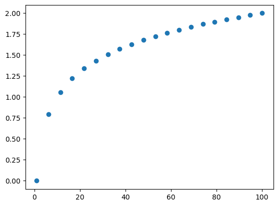

```python
# This "magic" command will embed plots directly in your notebook
%matplotlib inline
# Import the function we need to make a scatter plot
from matplotlib.pyplot import scatter
# We'll discuss the two previous commands in a little more detail soon!
# Fill in the ??? based on your answers to questions 1 and 2.
x = np.linspace(1, 100, 20) #staring at 1 going to 100 in steps of 5 20 points
y = np.log10(x) #defing y as f unction x as y = log(base10)(x)
print(x) # checking x is correct
print(y) #checking that y is correct
# plots the x and y
scatter(x, y); # notice the semi-colon here
```

# 7 think+type: arrays and functions

```python
def sum_of_squares(x):
    '''

    ----input-----

    x is a numpy array

    ----ouputs-----

    "if we take every element in array: "
    x
    "Every element in the array squared is: "
    array1
    "The sum of these squares is: "
    array 2

    '''
    squares = x**2 # defining squares as every element in the aray x sqaured
    sum_squares = np.sum(squares) # defing sum_squares as the sum of every element in squares
    print("the original array is, \n",
    x, "\n",
    "Every element in the array squared is: \n",
    squares, "\n",
    "The sum of these squares is: \n",
    sum_squares )

    return(sum_squares) #if you just want the output
```

```python
x= np.array([2, 4, 8, 16])
sum_of_squares(x)
```

```
the original array is,
 [ 2  4  8 16]
 Every element in the array squared is:
 [  4  16  64 256]
 The sum of these squares is:
 340
```

```
340
```

```python
# testing if the sum_of_squares function can be used to solve the pythagorean theorum
sides = np.array([5,12])
hypotenuse = np.sqrt(sum_of_squares(sides))
print("the hypotenuse is, ", hypotenuse)
```

```
the original array is,
 [ 5 12]
 Every element in the array squared is:
 [ 25 144]
 The sum of these squares is:
 169
the hypotenuse is,  13.0
```

I probably could have cut the print statement out of the function, but I din't need to